# 01_Deriving_Risk_Difference

Arthur M. Albuquerque

May 13, 2021

In this document, I will provide the rationale for the effect sizes used in our project.

First, I will load the data and calculate the log-odds ratio (OR) of the RECOVERY trial and its corresponding prior included in our analyses. Next, I will use these calculate the odds ratio and then derive the risk differences.

# Data

```r
# Load packages

# Ensures the package "pacman" is installed
if (!require("pacman")) install.packages("pacman")
```

```r
# p_load() installs (if necessary) and loads the following packages

pacman::p_load(rio, # to import/export files
               tidyverse, # Data wrangling and plotting
               kableExtra, # To create tables
               flextable, # To create tables
               here, # To find file paths within R project
               metafor, # To create priors from meta-analysis
               janitor, # To change column names
               ggdist, # To plot distributions
               patchwork # To arrange plots
               )

# Load data on respiratory support subgroups

d1 = import((here("final_analyses", "output", "data", # file path
                   "respiratory-data.csv")),           # file name
             header = T)

# Load data on corticosteroids subgroups

d2 = import(here("final_analyses", "data", # file path
                            "corticosteroids_subgroup_extracted-data.xlsx"))

d2 = clean_names(d2)
```

Here is a sneak peak in the table on respiratory support subgroups.

```r
d1 %>%
  group_by(trial, outcome) %>%
  count() %>%
  rename("number of subgroups" = n) %>%
  flextable() %>%
  autofit()
```

| trial | outcome | number of subgroups |
| --- | --- | --- |
| CORIMUNO-19 | discharge | 1 |
| CORIMUNO-19 | mortality | 1 |
| COVACTA | discharge | 3 |
| COVACTA | mortality | 3 |
| RECOVERY | discharge | 3 |
| RECOVERY | mortality | 3 |
| REMAP-CAP | discharge | 1 |
| REMAP-CAP | mortality | 2 |
| Salvarini | discharge | 1 |
| Salvarini | mortality | 1 |
| TOCIBRAS | discharge | 1 |
| TOCIBRAS | mortality | 1 |

Here is a sneak peak in the table on **respiratory support** subgroups.

```r
d1 %>%
  group_by(trial, outcome) %>%
  count() %>%
  rename("number of subgroups" = n) %>%
  flextable() %>%
  autofit()
```

| trial | outcome | number of subgroups |
| --- | --- | --- |
| CORIMUNO-19 | discharge | 1 |
| CORIMUNO-19 | mortality | 1 |
| COVACTA | discharge | 3 |
| COVACTA | mortality | 3 |
| RECOVERY | discharge | 3 |
| RECOVERY | mortality | 3 |
| REMAP-CAP | discharge | 1 |
| REMAP-CAP | mortality | 2 |
| Salvarini | discharge | 1 |
| Salvarini | mortality | 1 |
| TOCIBRAS | discharge | 1 |
| TOCIBRAS | mortality | 1 |

Here is a sneak peak in the table on **corticosteroids** subgroups.

```r
d2 %>%
  group_by(trial, outcome) %>%
  count() %>%
  rename("number of subgroups" = n) %>%
  flextable() %>%
  autofit()
```

| trial | outcome | number of subgroups |
| --- | --- | --- |
| COVACTA | discharge | 2 |
| COVACTA | mortality | 2 |
| RECOVERY | discharge | 2 |
| RECOVERY | mortality | 2 |
| REMAP-CAP | mortality | 2 |

# Odds ratio, then risk difference

Our ultimate goal in this project is to report posterior distributions of risk difference (RD) for each subgroup. We will eventually compile multiple studies in our analyses and each have their own baseline risk (BR). Notably, RD is intrinsically related to BR. Therefore, different studies with distinct RDs are not comparable between each other.

To overcome this limitation regarding RD, we have decided to use a fixed BR for each subgroup. We will use the BR in the respective control group from the RECOVERY trial.

Doi et al. stated that RD should be derived from the odds ratio (OR). Thus, in combination with a fixed BR we will calculate RDs from OR. Here is the formula provided by Doi et al., where $R D$ is risk difference, $B R$ is baseline risk from the control group (no-exposure) and $O R$ is odds ratio.

$$

$$\begin{aligned}
R D=\frac{B R * \left(B R-1\right)* \left(O R-1\right)}{B R*O R-B R+1}
\end{aligned}$$

$$

## Mortality outcome

### Use of corticosteroids subgroups

#### Not using

First, let’s calculate and visualize the **log-odds ratio** from the RECOVERY trial.

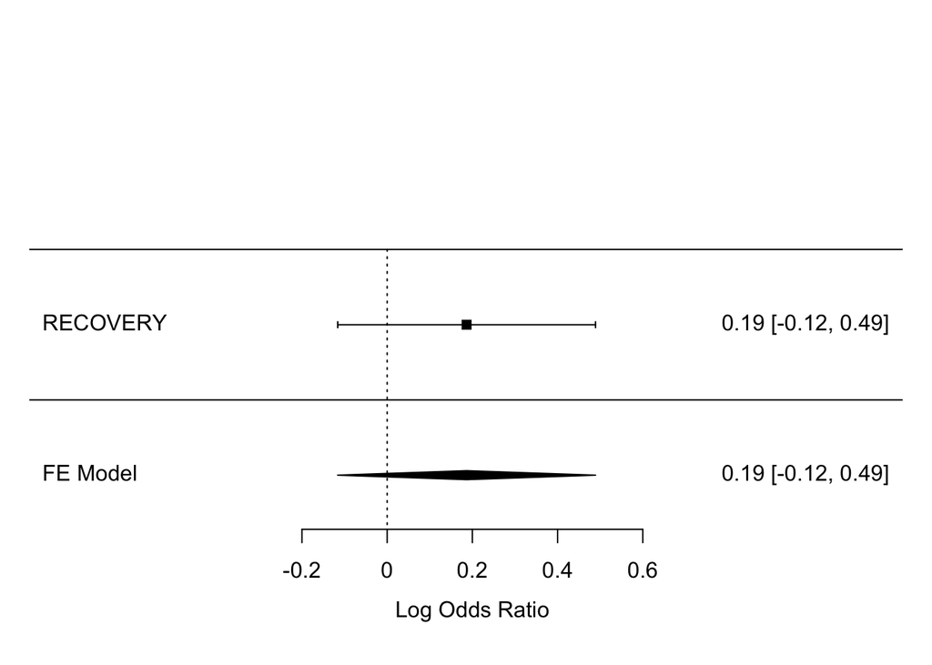

```r
recovery_not_using =
  escalc(
    # Outcome
    measure = "OR", # Log-odds ratio

    # Tocilizumab group
    ai = events_toci,
    n1i = total_toci,

    # Control group
    ci = events_control,
    n2i = total_control,

    data = d2 %>% filter(outcome == "mortality",
                         corticosteroids == 0,
                         trial == "RECOVERY"),

    slab = paste(trial)
  )

logOR_recovery_not_using = rma(yi, vi, data=recovery_not_using)

forest(logOR_recovery_not_using)
```

Now, let’s calculate and visualize the **log-odds ratio** from the other trials. The pooled result from this random-effect meta-analysis will be used as the estimate for the distribution of prior regarding this subgroup.

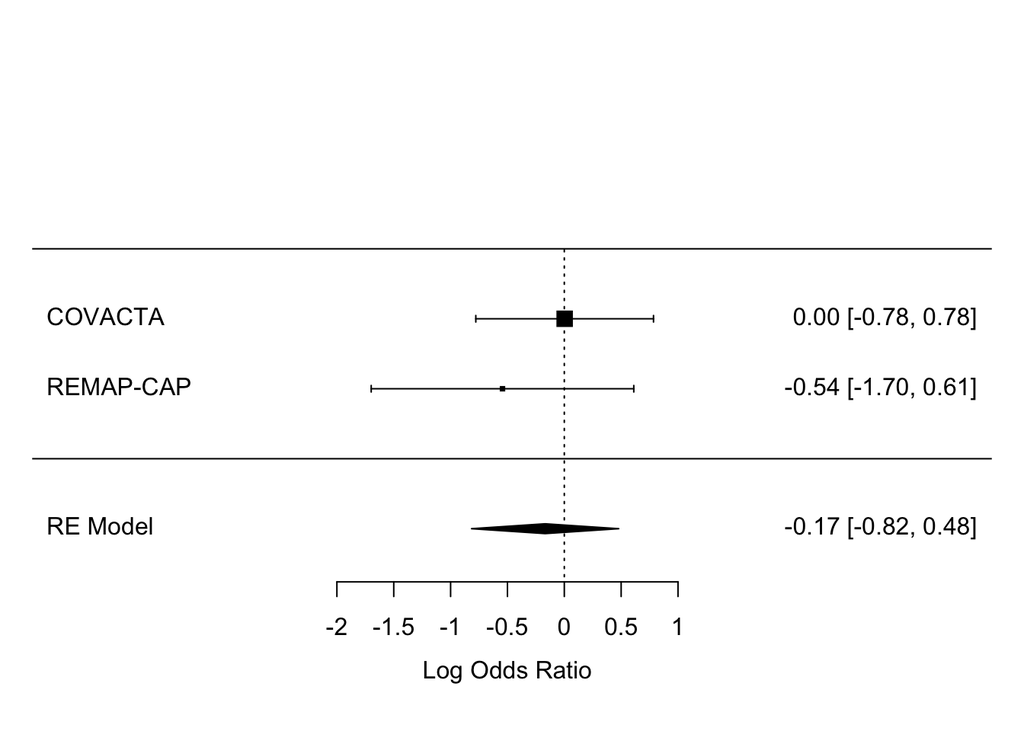

```r
# Simple oxygen

prior_not_using =
  escalc(
    # Outcome
    measure = "OR", # Log-odds ratio

    # Tocilizumab group
    ai = events_toci,
    n1i = total_toci,

    # Control group
    ci = events_control,
    n2i = total_control,

    data = d2 %>% filter(outcome == "mortality",
                         corticosteroids == 0,
                         trial != "RECOVERY"),

    slab = paste(trial)
  )

logOR_prior_not_using = rma(yi, vi, data=prior_not_using)

forest(logOR_prior_not_using)
```

#### Using

Let’s calculate and visualize the **log-odds ratio** from the RECOVERY trial.

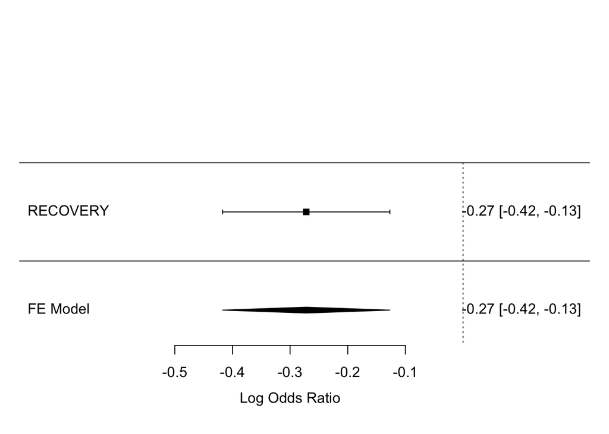

```r
recovery_using =
  escalc(
    # Outcome
    measure = "OR", # Log-odds ratio

    # Tocilizumab group
    ai = events_toci,
    n1i = total_toci,

    # Control group
    ci = events_control,
    n2i = total_control,

    data = d2 %>% filter(outcome == "mortality",
                         corticosteroids == 1,
                         trial == "RECOVERY"),

    slab = paste(trial)
  )

logOR_recovery_using = rma(yi, vi, data=recovery_using)

forest(logOR_recovery_using)
```

Now, let’s calculate and visualize the **log-odds ratio** from the other trials. The pooled result from this random-effect meta-analysis will be used as the estimate for the distribution of prior regarding this subgroup.

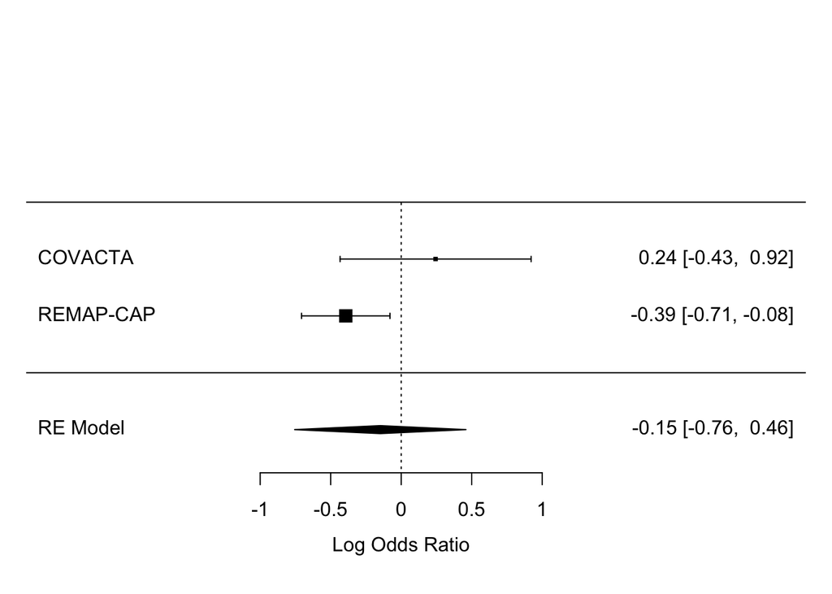

```r
# Simple oxygen

prior_using =
  escalc(
    # Outcome
    measure = "OR", # Log-odds ratio

    # Tocilizumab group
    ai = events_toci,
    n1i = total_toci,

    # Control group
    ci = events_control,
    n2i = total_control,

    data = d2 %>% filter(outcome == "mortality",
                         corticosteroids == 1,
                         trial != "RECOVERY"),

    slab = paste(trial)
  )

logOR_prior_using = rma(yi, vi, data=prior_using)

forest(logOR_prior_using)
```

### Respiratory support subgroups

#### Simple oxygen only

Let’s calculate and visualize the **log-odds ratio** from the RECOVERY trial.

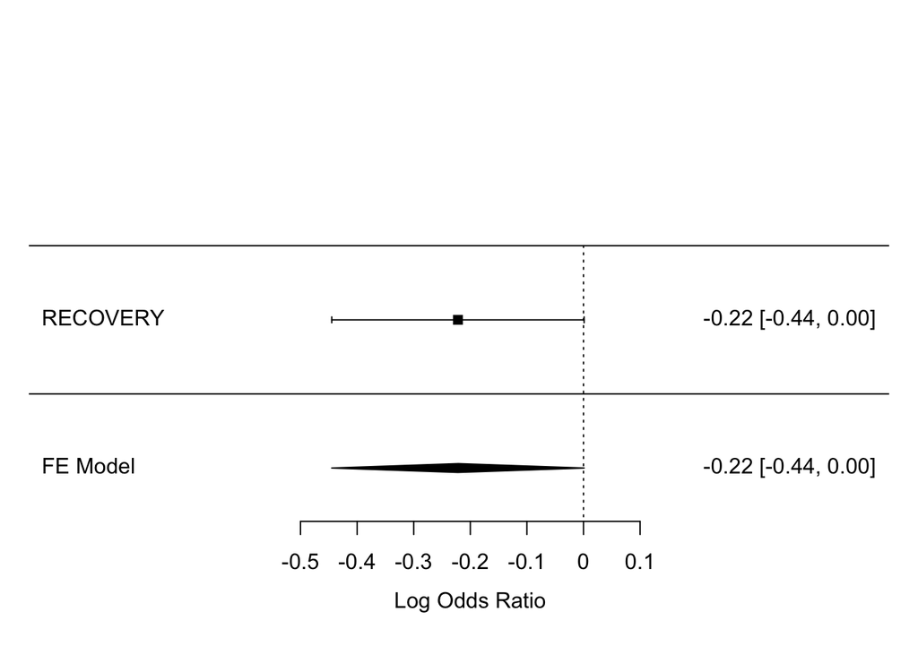

```r
recovery_simple =
  escalc(
    # Outcome
    measure = "OR", # Log-odds ratio

    # Tocilizumab group
    ai = events_toci,
    n1i = total_toci,

    # Control group
    ci = events_control,
    n2i = total_control,

    data = d1 %>% filter(outcome == "mortality",
                         oxygen == "simple oxygen",
                         trial == "RECOVERY"),

    slab = paste(trial)
  )

logOR_recovery_simple = rma(yi, vi, data=recovery_simple)

forest(logOR_recovery_simple)
```

Now, let’s calculate and visualize the **log-odds ratio** from the other trials. The pooled result from this random-effect meta-analysis will be used as the estimate for the distribution of prior regarding this subgroup.

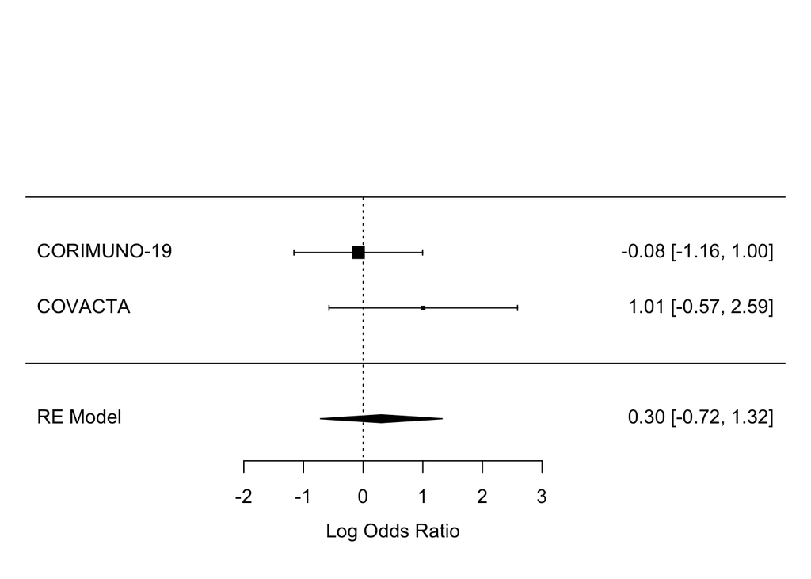

```r
prior_simple =
  escalc(
    # Outcome
    measure = "OR", # Log-odds ratio

    # Tocilizumab group
    ai = events_toci,
    n1i = total_toci,

    # Control group
    ci = events_control,
    n2i = total_control,

    data = d1 %>% filter(outcome == "mortality",
                         oxygen == "simple oxygen",
                         trial != "RECOVERY"),

    slab = paste(trial)
  )

logOR_prior_simple = rma(yi, vi, data=prior_simple)

forest(logOR_prior_simple)
```

#### Non-invasive ventilation

Let’s calculate and visualize the **log-odds ratio** from the RECOVERY trial.

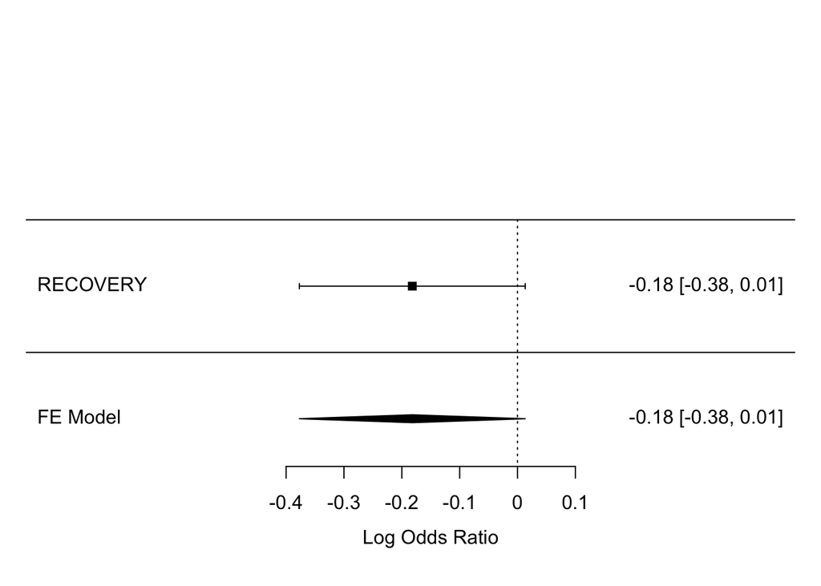

```r
recovery_noninvasive =
  escalc(
    # Outcome
    measure = "OR", # Log-odds ratio

    # Tocilizumab group
    ai = events_toci,
    n1i = total_toci,

    # Control group
    ci = events_control,
    n2i = total_control,

    data = d1 %>% filter(outcome == "mortality",
                         oxygen == "non-invasive ventilation",
                         trial == "RECOVERY"),

    slab = paste(trial)
  )

logOR_recovery_noninvasive = rma(yi, vi, data=recovery_noninvasive)

forest(logOR_recovery_noninvasive)
```

Now, let’s calculate and visualize the **log-odds ratio** from the other trials. The pooled result from this random-effect meta-analysis will be used as the estimate for the distribution of prior regarding this subgroup.

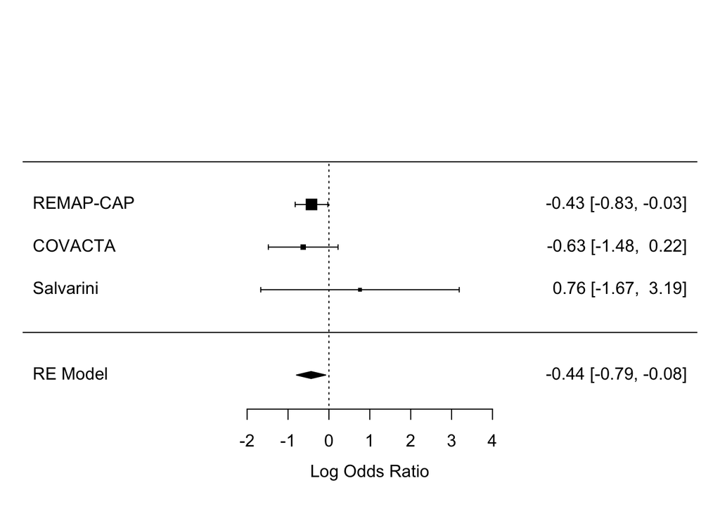

```r
prior_noninvasive =
  escalc(
    # Outcome
    measure = "OR", # Log-odds ratio

    # Tocilizumab group
    ai = events_toci,
    n1i = total_toci,

    # Control group
    ci = events_control,
    n2i = total_control,

    data = d1 %>% filter(outcome == "mortality",
                         oxygen == "non-invasive ventilation",
                         trial != "RECOVERY"),

    slab = paste(trial)
  )

logOR_prior_noninvasive = rma(yi, vi, data=prior_noninvasive)

forest(logOR_prior_noninvasive)
```

#### Invasive mechanical ventilation

Let’s calculate and visualize the **log-odds ratio** from the RECOVERY trial.

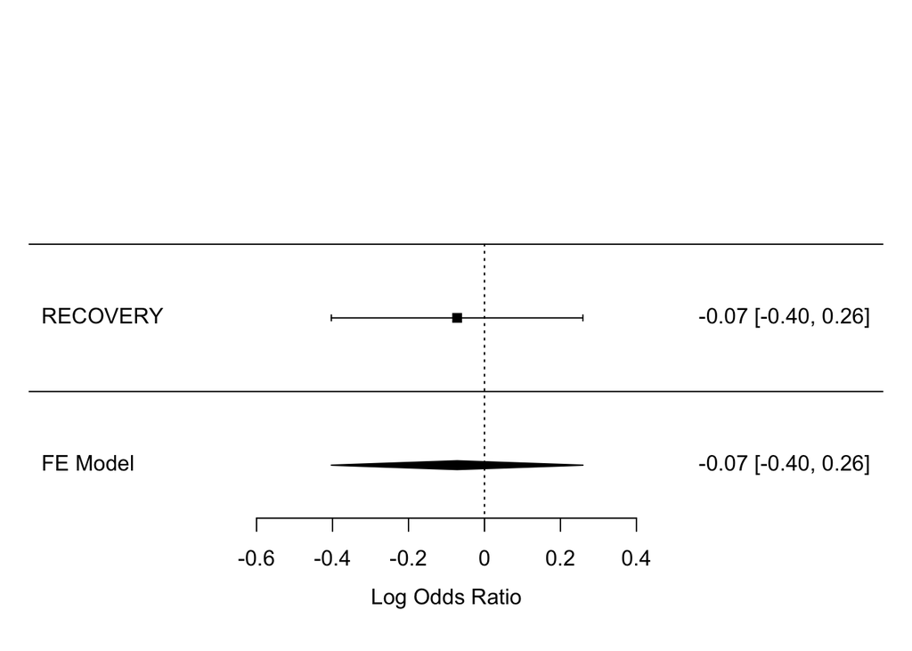

```r
recovery_invasive =
  escalc(
    # Outcome
    measure = "OR", # Log-odds ratio

    # Tocilizumab group
    ai = events_toci,
    n1i = total_toci,

    # Control group
    ci = events_control,
    n2i = total_control,

    data = d1 %>% filter(outcome == "mortality",
                         oxygen == "invasive ventilation",
                         trial == "RECOVERY"),

    slab = paste(trial)
  )

logOR_recovery_invasive = rma(yi, vi, data=recovery_invasive)

forest(logOR_recovery_invasive)
```

Now, let’s calculate and visualize the **log-odds ratio** from the other trials. The pooled result from this random-effect meta-analysis will be used as the estimate for the distribution of prior regarding this subgroup.

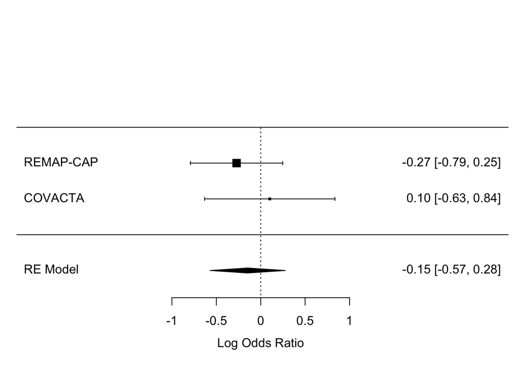

```r
prior_invasive =
  escalc(
    # Outcome
    measure = "OR", # Log-odds ratio

    # Tocilizumab group
    ai = events_toci,
    n1i = total_toci,

    # Control group
    ci = events_control,
    n2i = total_control,

    data = d1 %>% filter(outcome == "mortality",
                         oxygen == "invasive ventilation",
                         trial != "RECOVERY"),

    slab = paste(trial)
  )

logOR_prior_invasive = rma(yi, vi, data=prior_invasive)

forest(logOR_prior_invasive)
```

### Calculating risk difference

As mentioned before, we will use the formula provided by Doi et al. to calculate the risk difference (RD) from a fixed baseline risk (BR) and odds odds ratio (OR).

$$

$$\begin{aligned}
R D=\frac{B R * \left(B R-1\right)* \left(O R-1\right)}{B R*O R-B R+1}
\end{aligned}$$

$$

In the sections before, we calculated the log-odds ratio for the RECOVEY trial and prior distributions for each subgroup. Of note, log-odds ratio is normal distributed.

Now, we will draw 100,000 samples using the log-odds ratio mean and its standard error for the RECOVERY trial and prior distributions for each subgroup. Next, we will exponentiate these values to obtain the odds ratio.

```r
### RECOVERY trial

set.seed = 123 # for reproducibility

n = 1e5

## Use of corticosteroids

### Not using

estimates_RECOVERY_not_using =
  tibble(
    logOR = rnorm(n, # Sampling size
        logOR_recovery_not_using$beta, # Mean
        logOR_recovery_not_using$se # Standard error
        )
    ) %>%
  mutate(OR = exp(logOR))

### Using

estimates_RECOVERY_using =
  tibble(
    logOR = rnorm(n, # Sampling size
        logOR_recovery_using$beta, # Mean
        logOR_recovery_using$se # Standard error
        )
    ) %>%
  mutate(OR = exp(logOR))

## Respiratory support

### Simple oxygen only

estimates_RECOVERY_simple =
  tibble(
    logOR = rnorm(n, # Sampling size
        logOR_recovery_simple$beta, # Mean
        logOR_recovery_simple$se # Standard error
        )
    ) %>%
  mutate(OR = exp(logOR))

### Non-invasive ventilation

estimates_RECOVERY_noninvasive =
  tibble(
    logOR = rnorm(n, # Sampling size
        logOR_recovery_noninvasive$beta, # Mean
        logOR_recovery_noninvasive$se # Standard error
        )
    ) %>%
  mutate(OR = exp(logOR))

### Invasive ventilation

estimates_RECOVERY_invasive =
  tibble(
    logOR = rnorm(n, # Sampling size
        logOR_recovery_invasive$beta, # Mean
        logOR_recovery_invasive$se # Standard error
        )
    ) %>%
  mutate(OR = exp(logOR))
```

```r
### Priors

set.seed = 123 # for reproducibility

n = 1e5

## Use of corticosteroids

### Not using

estimates_prior_not_using =
  tibble(
    logOR = rnorm(n, # Sampling size
                  logOR_prior_not_using$beta, # Mean
                  logOR_prior_not_using$se # Standard error
    )
  ) %>%
  mutate(OR = exp(logOR))

### Using

estimates_prior_using =
  tibble(
    logOR = rnorm(n, # Sampling size
                  logOR_prior_using$beta, # Mean
                  logOR_prior_using$se # Standard error
    )
  ) %>%
  mutate(OR = exp(logOR))

## Respiratory support

### Simple oxygen only

estimates_prior_simple =
  tibble(
    logOR = rnorm(n, # Sampling size
                  logOR_prior_simple$beta, # Mean
                  logOR_prior_simple$se # Standard error
    )
  ) %>%
  mutate(OR = exp(logOR))

### Non-invasive ventilation

estimates_prior_noninvasive =
  tibble(
    logOR = rnorm(n, # Sampling size
                  logOR_prior_noninvasive$beta, # Mean
                  logOR_prior_noninvasive$se # Standard error
    )
  ) %>%
  mutate(OR = exp(logOR))

### Invasive ventilation

estimates_prior_invasive =
  tibble(
    logOR = rnorm(n, # Sampling size
                  logOR_prior_invasive$beta, # Mean
                  logOR_prior_invasive$se # Standard error
    )
  ) %>%
  mutate(OR = exp(logOR))
```

Lastly, we will apply the function above to calculate the corresponding risk difference for each odds ratio. Here are the baseline risks from the control groups that will be used, based on the RECOVERY trial:

```r
tibble(

  "Subgroup" = c("Not using",
                 "Using",

                 "Simple oxygen only",
                 "Non-invasive ventilation",
                 "Invasive mechanical"
                 ),

  "Baseline Risk in Control Group (%)" = c(

    d2 %>%
    filter(trial == "RECOVERY",
           corticosteroids == 0,
           outcome == "mortality") %>%
      summarise(n = 100*(events_control/total_control)) %>%
      round(., 1) %>%
      pull(),
    d2 %>%
    filter(trial == "RECOVERY",
           corticosteroids == 1,
           outcome == "mortality") %>%
      summarise(n = 100*(events_control/total_control)) %>%
      round(., 1) %>%
      pull(),

    d1 %>%
    filter(trial == "RECOVERY",
           oxygen == "simple oxygen",
           outcome == "mortality") %>%
      summarise(n = 100*(events_control/total_control)) %>%
      round(., 1) %>%
      pull(),
    d1 %>%
    filter(trial == "RECOVERY",
           oxygen == "non-invasive ventilation",
           outcome == "mortality") %>%
      summarise(n = 100*(events_control/total_control)) %>%
      round(., 1) %>%
      pull(),
    d1 %>%
    filter(trial == "RECOVERY",
           oxygen == "invasive ventilation",
           outcome == "mortality") %>%
      summarise(n = 100*(events_control/total_control)) %>%
      round(., 1) %>%
      pull()
  )

) %>%
  kbl(booktabs = T, align = 'c') %>%
  kable_styling(bootstrap_options = "striped", full_width = F) %>%
  pack_rows("Use of corticosteroids", 1, 2) %>%
  pack_rows("Respiratory support", 3, 5)
```

| Subgroup | Baseline Risk in Control Group (%) |
| --- | --- |
| **Use of corticosteroids** |  |
| Not using | 34.6 |
| Using | 34.9 |
| **Respiratory support** |  |
| Simple oxygen only | 22.9 |
| Non-invasive ventilation | 42.2 |
| Invasive mechanical | 50.7 |

```r
# Formula from Doi et al., 2020

RD_fun = function(BR,OR)
  {
( BR*(BR-1)*(OR-1) ) / ( BR*OR - BR+1)
}
```

```r
# Calculating the risk differences

#### RECOVERY

### Use of corticosteroids

## Not using

# Define baseline risk
BR_not_using = d2 %>%
    filter(trial == "RECOVERY",
           corticosteroids == 0, # Not using
           outcome == "mortality") %>%
      summarise(n = events_control/total_control) %>%
      pull()

estimates_RECOVERY_not_using =
  estimates_RECOVERY_not_using %>%
  # Apply formula from Doi et al., 2020
  mutate(RD = RD_fun(BR_not_using,
                     OR))

## Using

# Define baseline risk
BR_using = d2 %>%
    filter(trial == "RECOVERY",
           corticosteroids == 1, # Using
           outcome == "mortality") %>%
      summarise(n = events_control/total_control) %>%
      pull()

estimates_RECOVERY_using =
  estimates_RECOVERY_using %>%
  # Apply formula from Doi et al., 2020
  mutate(RD = RD_fun(BR_using,
                     OR))

### Respiratory support

## Simple oxygen

# Define baseline risk
BR_simple = d1 %>%
    filter(trial == "RECOVERY",
           oxygen == "simple oxygen",
           outcome == "mortality") %>%
      summarise(n = events_control/total_control) %>%
      pull()

estimates_RECOVERY_simple =
  estimates_RECOVERY_simple %>%
  # Apply formula from Doi et al., 2020
  mutate(RD = RD_fun(BR_simple,
                     OR))

## Non-invasive

# Define baseline risk
BR_noninvasive = d1 %>%
    filter(trial == "RECOVERY",
           oxygen == "non-invasive ventilation",
           outcome == "mortality") %>%
      summarise(n = events_control/total_control) %>%
      pull()

estimates_RECOVERY_noninvasive =
  estimates_RECOVERY_noninvasive %>%
  # Apply formula from Doi et al., 2020
  mutate(RD = RD_fun(BR_noninvasive,
                     OR))

## Invasive mechanical ventilation

# Define baseline risk
BR_invasive = d1 %>%
    filter(trial == "RECOVERY",
           oxygen == "invasive ventilation",
           outcome == "mortality") %>%
      summarise(n = events_control/total_control) %>%
      pull()

estimates_RECOVERY_invasive =
  estimates_RECOVERY_invasive %>%
  # Apply formula from Doi et al., 2020
  mutate(RD = RD_fun(BR_invasive,
                     OR))
```

```r
#### Priors

# The baseline risks are defined in the code chunk above

### Use of corticosteroids

## Not using

estimates_prior_not_using =
  estimates_prior_not_using %>%
  # Apply formula from Doi et al., 2020
  mutate(RD = RD_fun(BR_not_using,
                     OR))

## Using

estimates_prior_using =
  estimates_prior_using %>%
  # Apply formula from Doi et al., 2020
  mutate(RD = RD_fun(BR_using,
                     OR))

### Respiratory support

## Simple oxygen

estimates_prior_simple =
  estimates_prior_simple %>%
  # Apply formula from Doi et al., 2020
  mutate(RD = RD_fun(BR_simple,
                     OR))

## Non-invasive

estimates_prior_noninvasive =
  estimates_prior_noninvasive %>%
  # Apply formula from Doi et al., 2020
  mutate(RD = RD_fun(BR_noninvasive,
                     OR))

## Invasive mechanical ventilation

estimates_prior_invasive =
  estimates_prior_invasive %>%
  # Apply formula from Doi et al., 2020
  mutate(RD = RD_fun(BR_invasive,
                     OR))
```

## Plotting

We will now plot the log-odds ratio, the odds ratio and the risk difference for each subgroup.

### Use of corticosteroids

#### Not using

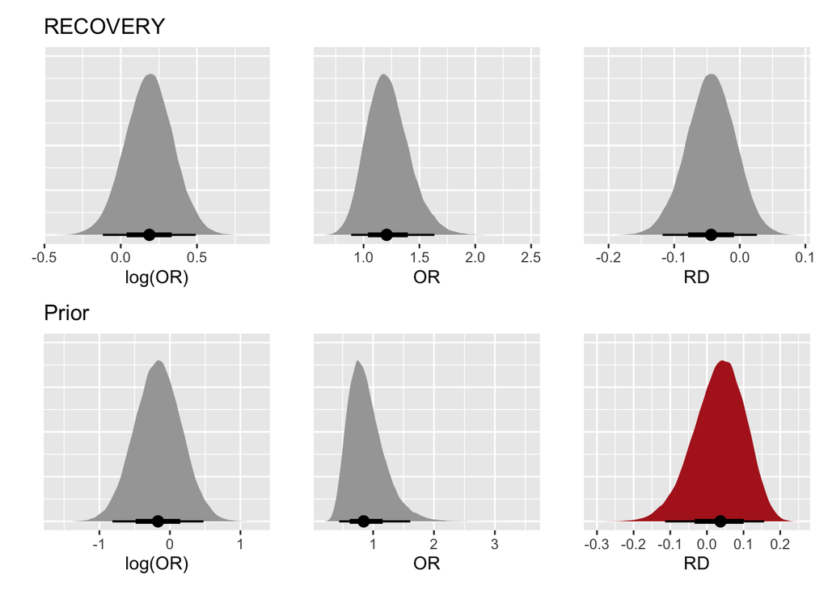

```r
p1 = estimates_RECOVERY_not_using %>%
  ggplot(aes(logOR)) +
  stat_halfeye() +
  labs(title = "RECOVERY",
       x = "log(OR)", y = " ") +
  theme(axis.text.y = element_blank(),
        axis.ticks.y = element_blank())

p2 = estimates_RECOVERY_not_using %>%
  ggplot(aes(OR)) +
  stat_halfeye() +
  labs(x = "OR", y = " ") +
  theme(axis.text.y = element_blank(),
        axis.ticks.y = element_blank())

p3 = estimates_RECOVERY_not_using %>%
  ggplot(aes(RD)) +
  stat_halfeye() +
  labs(x = "RD", y = " ") +
  theme(axis.text.y = element_blank(),
        axis.ticks.y = element_blank())

p4 = estimates_prior_not_using %>%
  ggplot(aes(logOR)) +
  stat_halfeye() +
  labs(title = "Prior",
       x = "log(OR)", y = " ") +
  theme(axis.text.y = element_blank(),
        axis.ticks.y = element_blank())

p5 = estimates_prior_not_using %>%
  ggplot(aes(OR)) +
  stat_halfeye() +
  labs(x = "OR", y = " ") +
  theme(axis.text.y = element_blank(),
        axis.ticks.y = element_blank())

p6 = estimates_prior_not_using %>%
  ggplot(aes(RD)) +
  stat_halfeye(fill = "firebrick") +
  labs(x = "RD", y = " ") +
  theme(axis.text.y = element_blank(),
        axis.ticks.y = element_blank())

(p1 + p2 + p3) / (p4 + p5 + p6)
```

#### Using

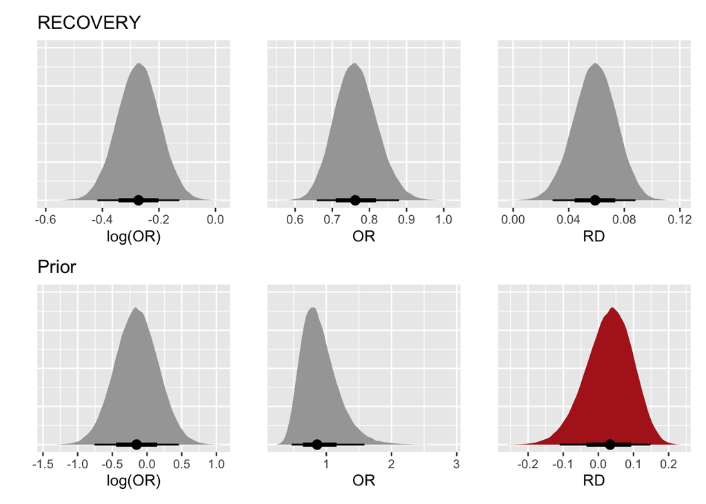

```r
p1 = estimates_RECOVERY_using %>%
  ggplot(aes(logOR)) +
  stat_halfeye() +
  labs(title = "RECOVERY",
       x = "log(OR)", y = " ") +
  theme(axis.text.y = element_blank(),
        axis.ticks.y = element_blank())

p2 = estimates_RECOVERY_using %>%
  ggplot(aes(OR)) +
  stat_halfeye() +
  labs(x = "OR", y = " ") +
  theme(axis.text.y = element_blank(),
        axis.ticks.y = element_blank())

p3 = estimates_RECOVERY_using %>%
  ggplot(aes(RD)) +
  stat_halfeye() +
  labs(x = "RD", y = " ") +
  theme(axis.text.y = element_blank(),
        axis.ticks.y = element_blank())

p4 = estimates_prior_using %>%
  ggplot(aes(logOR)) +
  stat_halfeye() +
  labs(title = "Prior",
       x = "log(OR)", y = " ") +
  theme(axis.text.y = element_blank(),
        axis.ticks.y = element_blank())

p5 = estimates_prior_using %>%
  ggplot(aes(OR)) +
  stat_halfeye() +
  labs(x = "OR", y = " ") +
  theme(axis.text.y = element_blank(),
        axis.ticks.y = element_blank())

p6 = estimates_prior_using %>%
  ggplot(aes(RD)) +
  stat_halfeye(fill = "firebrick") +
  labs(x = "RD", y = " ") +
  theme(axis.text.y = element_blank(),
        axis.ticks.y = element_blank())

(p1 + p2 + p3) / (p4 + p5 + p6)
```

### Respiratory support

#### Simple oxygen only

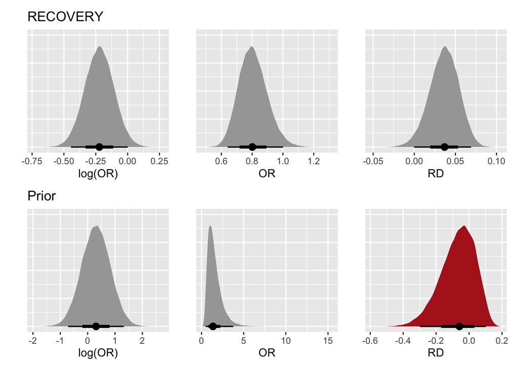

```r
p1 = estimates_RECOVERY_simple %>%
  ggplot(aes(logOR)) +
  stat_halfeye() +
  labs(title = "RECOVERY",
       x = "log(OR)", y = " ") +
  theme(axis.text.y = element_blank(),
        axis.ticks.y = element_blank())

p2 = estimates_RECOVERY_simple %>%
  ggplot(aes(OR)) +
  stat_halfeye() +
  labs(x = "OR", y = " ") +
  theme(axis.text.y = element_blank(),
        axis.ticks.y = element_blank())

p3 = estimates_RECOVERY_simple %>%
  ggplot(aes(RD)) +
  stat_halfeye() +
  labs(x = "RD", y = " ") +
  theme(axis.text.y = element_blank(),
        axis.ticks.y = element_blank())

p4 = estimates_prior_simple %>%
  ggplot(aes(logOR)) +
  stat_halfeye() +
  labs(title = "Prior",
       x = "log(OR)", y = " ") +
  theme(axis.text.y = element_blank(),
        axis.ticks.y = element_blank())

p5 = estimates_prior_simple %>%
  ggplot(aes(OR)) +
  stat_halfeye() +
  labs(x = "OR", y = " ") +
  theme(axis.text.y = element_blank(),
        axis.ticks.y = element_blank())

p6 = estimates_prior_simple %>%
  ggplot(aes(RD)) +
  stat_halfeye(fill = "firebrick") +
  labs(x = "RD", y = " ") +
  theme(axis.text.y = element_blank(),
        axis.ticks.y = element_blank())

(p1 + p2 + p3) / (p4 + p5 + p6)
```

#### Non-invasive ventilation

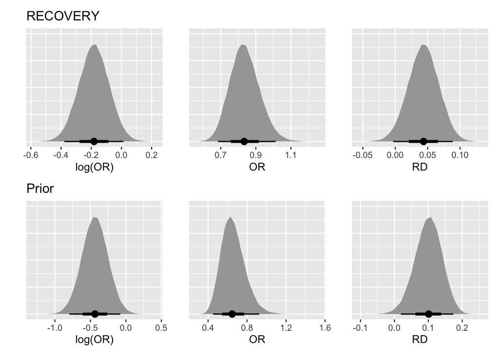

```r
p1 = estimates_RECOVERY_noninvasive %>%
  ggplot(aes(logOR)) +
  stat_halfeye() +
  labs(title = "RECOVERY",
       x = "log(OR)", y = " ") +
  theme(axis.text.y = element_blank(),
        axis.ticks.y = element_blank())

p2 = estimates_RECOVERY_noninvasive %>%
  ggplot(aes(OR)) +
  stat_halfeye() +
  labs(x = "OR", y = " ") +
  theme(axis.text.y = element_blank(),
        axis.ticks.y = element_blank())

p3 = estimates_RECOVERY_noninvasive %>%
  ggplot(aes(RD)) +
  stat_halfeye() +
  labs(x = "RD", y = " ") +
  theme(axis.text.y = element_blank(),
        axis.ticks.y = element_blank())

p4 = estimates_prior_noninvasive %>%
  ggplot(aes(logOR)) +
  stat_halfeye() +
  labs(title = "Prior",
       x = "log(OR)", y = " ") +
  theme(axis.text.y = element_blank(),
        axis.ticks.y = element_blank())

p5 = estimates_prior_noninvasive %>%
  ggplot(aes(OR)) +
  stat_halfeye() +
  labs(x = "OR", y = " ") +
  theme(axis.text.y = element_blank(),
        axis.ticks.y = element_blank())

p6 = estimates_prior_noninvasive %>%
  ggplot(aes(RD)) +
  stat_halfeye() +
  labs(x = "RD", y = " ") +
  theme(axis.text.y = element_blank(),
        axis.ticks.y = element_blank())

(p1 + p2 + p3) / (p4 + p5 + p6)
```

#### Invasive mechanical ventilation

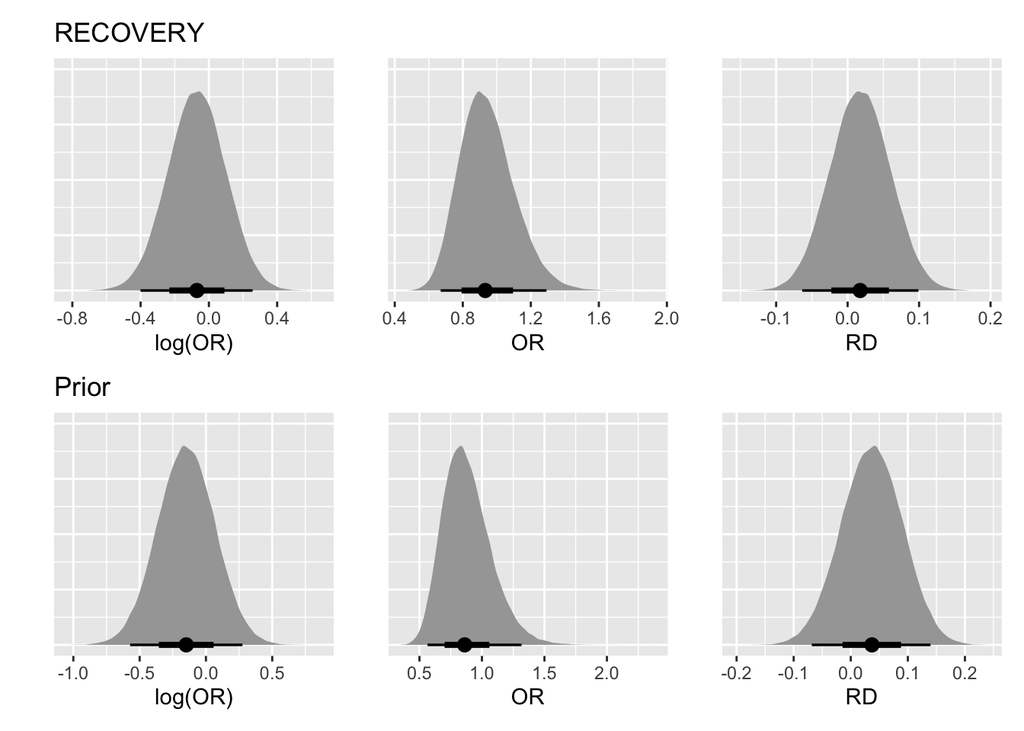

```r
p1 = estimates_RECOVERY_invasive %>%
  ggplot(aes(logOR)) +
  stat_halfeye() +
  labs(title = "RECOVERY",
       x = "log(OR)", y = " ") +
  theme(axis.text.y = element_blank(),
        axis.ticks.y = element_blank())

p2 = estimates_RECOVERY_invasive %>%
  ggplot(aes(OR)) +
  stat_halfeye() +
  labs(x = "OR", y = " ") +
  theme(axis.text.y = element_blank(),
        axis.ticks.y = element_blank())

p3 = estimates_RECOVERY_invasive %>%
  ggplot(aes(RD)) +
  stat_halfeye() +
  labs(x = "RD", y = " ") +
  theme(axis.text.y = element_blank(),
        axis.ticks.y = element_blank())

p4 = estimates_prior_invasive %>%
  ggplot(aes(logOR)) +
  stat_halfeye() +
  labs(title = "Prior",
       x = "log(OR)", y = " ") +
  theme(axis.text.y = element_blank(),
        axis.ticks.y = element_blank())

p5 = estimates_prior_invasive %>%
  ggplot(aes(OR)) +
  stat_halfeye() +
  labs(x = "OR", y = " ") +
  theme(axis.text.y = element_blank(),
        axis.ticks.y = element_blank())

p6 = estimates_prior_invasive %>%
  ggplot(aes(RD)) +
  stat_halfeye() +
  labs(x = "RD", y = " ") +
  theme(axis.text.y = element_blank(),
        axis.ticks.y = element_blank())

(p1 + p2 + p3) / (p4 + p5 + p6)
```